# Another_view_cont

```r
library(readxl)
library(dplyr)
library(ggplot2)
library(reshape2)
```

## Климатические данные

Добавил к числу BIO1-BIO15 еще параметры из Clim_upd_New.xlsx

```r
clim <- read_excel("Data/bioclim.xlsx")

clim$Year <- as.numeric(clim$Year)

clim <-
  clim %>%
  filter(Year >= 2000)

library(vegan)

pca_clim <- rda(clim[,-1], scale = T)
```

Распределение собственных чисел

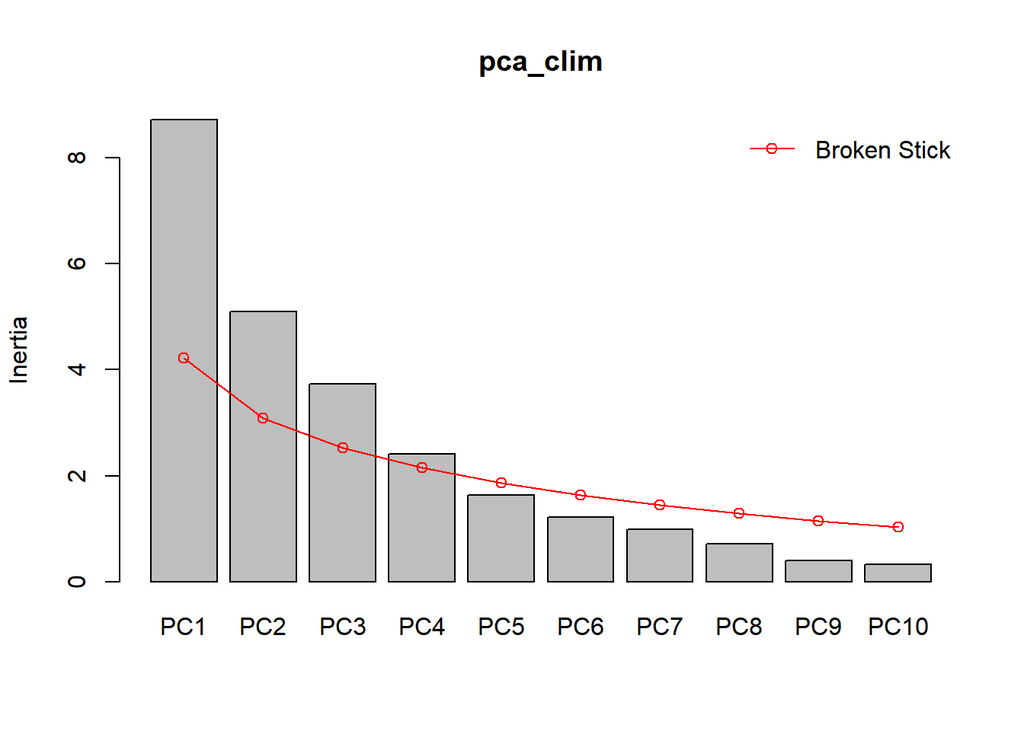

```r
screeplot(pca_clim, bstick = T)
```

Можно говорить про четыре главные компоненты

```r
PC_scores <- as.data.frame(scores(pca_clim, choices = 1:4)$species)
```

По первой PC максимальную связь имеет:

```r
PC_scores %>% filter(abs(PC1) == max(abs(PC1)))
```

```
##             PC1        PC2       PC3        PC4
## bio1 -0.8905317 -0.0421306 0.2454441 0.09445837
```

По второй PC максимальную связь имеет:

```r
PC_scores %>% filter(abs(PC2) == max(abs(PC2)))
```

```
##                 PC1        PC2        PC3        PC4
## CMIsummer 0.2447869 -0.8531373 -0.2070997 -0.1333679
```

По третьей PC максимальную связь имеет:

```r
PC_scores %>% filter(abs(PC3) == max(abs(PC3)))
```

```
##             PC1        PC2       PC3       PC4
## bio3 0.04398696 -0.1425097 0.7356027 0.3547663
```

По четвертой PC максимальную связь имеет:

```r
PC_scores %>% filter(abs(PC4) == max(abs(PC4)))
```

```
##             PC1        PC2       PC3       PC4
## bio15 0.4336852 -0.4345832 0.1533137 0.5975957
```

Теперь кандидаты на то, чтобы войти в число неколлинеарных предикторов, выглядят вот так

- BIO1 = Annual Mean Temperature
- CMIsummer
- BIO3 = Isothermality (BIO2/BIO7) (×100)
- BIO15 = Precipitation Seasonality (Coefficient of Variation)

Кстати, а что такое CMIsummer?

На всякий случай смотрим на корреляции между этими параметрами

```r
clim %>%
  select(bio1, CMIsummer, bio3, bio15) %>%
  cor()
```

```
##                 bio1   CMIsummer        bio3      bio15
## bio1       1.0000000 -0.24082369  0.10085571 -0.2997143
## CMIsummer -0.2408237  1.00000000 -0.02793072  0.3181616
## bio3       0.1008557 -0.02793072  1.00000000  0.3091259
## bio15     -0.2997143  0.31816163  0.30912594  1.0000000
```

Супер сильных корреляцй нет

```r
clim_short <-
  clim %>%
  select(Year, bio1, CMIsummer, bio3, bio15)
```

## Фенометрики

Да, теперь я понял. Действительно логично для этого анализа брать выборку по всем случайным точкам.

```r
evi <-
  read_excel("Data/Фенология по случайным сайтам/picea_phenological_data.xlsx", sheet = "picea.gsdt.evi") %>%
  select(sample.id, year, evi.max) %>%
  rename(Year = year) %>%
  filter(Year > 1999 & Year < 2024) %>%
  rename(Plot = sample.id)

evi2 <-
  read_excel("Data/Фенология по случайным сайтам/picea_phenological_data.xlsx", sheet = "picea.gsdt.evi2") %>%
  select(sample.id, year, evi2.max) %>%
  rename(Year = year) %>%
  filter(Year > 1999 & Year < 2024) %>%
  rename(Plot = sample.id)


kndvi <-
  read_excel("Data/Фенология по случайным сайтам/picea_phenological_data.xlsx", sheet = "picea.gsdt.kndvi") %>%
  select(sample.id, year, kndvi.max) %>%
  rename(Year = year) %>%
  filter(Year > 1999 & Year < 2024) %>%
  rename(Plot = sample.id)

ndvi <-
  read_excel("Data/Фенология по случайным сайтам/picea_phenological_data.xlsx", sheet = "picea.gsdt.ndvi") %>%
  select(sample.id, year, ndvi.max) %>%
  rename(Year = year) %>%
  filter(Year > 1999 & Year < 2024) %>%
  rename(Plot = sample.id)


nirv <-
  read_excel("Data/Фенология по случайным сайтам/picea_phenological_data.xlsx", sheet = "picea.gsdt.nirv") %>%
  select(sample.id, year, nirv.max) %>%
  rename(Year = year) %>%
  filter(Year > 1999 & Year < 2024) %>%
  rename(Plot = sample.id)
```

```r
set.seed(12345)

resample_n <- 1000
year_num <- round(length(unique(evi2$Year)) * 0.6)
site_num <- round(length(unique(evi2$Plot)) * 0.6)

years_full <- unique(clim$Year)

sites_full <- unique(evi$Plot)

######################

cors_evi <- data.frame(Index = rep("evi", resample_n))


for(i in 1:resample_n){

  years <- sample(years_full, size = year_num)
  Site <- sample(sites_full, size = site_num)


  x <-
    evi %>%
    filter(Plot %in% Site & Year %in% years)

  y <-
    clim_short %>%
    filter(Year %in% years)

  df <- merge(x, y, all.x = T) %>% filter(complete.cases(.))

  mod <- lm(evi.max ~ scale(bio1) + scale(CMIsummer) + scale(bio3) + scale(bio15) , data = df)

  cors_evi$bio1[i] <- coef(mod)[2]
  cors_evi$CMIsummer[i] <- coef(mod)[3]
  cors_evi$bio3[i] <- coef(mod)[4]
  cors_evi$bio15[i] <- coef(mod)[5]
  cors_evi$R2[i] <- summary(mod)$adj.r.squared
}

#########################################
cors_evi2 <- data.frame(Index = rep("evi2", resample_n))


for(i in 1:resample_n){

  years <- sample(years_full, size = year_num)
  Site <- sample(sites_full, size = site_num)

  x <-
    evi2 %>%
    filter(Plot %in% Site & Year %in% years)

  y <-
    clim_short %>%
    filter(Year %in% years)

 df <- merge(x, y, all.x = T) %>% filter(complete.cases(.))

  mod <- lm(evi2.max ~ scale(bio1) + scale(CMIsummer) + scale(bio3) + scale(bio15) , data = df)

  cors_evi2$bio1[i] <- coef(mod)[2]
  cors_evi2$CMIsummer[i] <- coef(mod)[3]
  cors_evi2$bio3[i] <- coef(mod)[4]
  cors_evi2$bio15[i] <- coef(mod)[5]
  cors_evi2$R2[i] <- summary(mod)$adj.r.squared

}

############################
cors_kndvi <- data.frame(Index = rep("kndvi", resample_n))


for(i in 1:resample_n){

  years <- sample(years_full, size = year_num)
  Site <- sample(sites_full, size = site_num)

  x <-
    kndvi %>%
    filter(Plot %in% Site & Year %in% years)

  y <-
    clim_short %>%
    filter(Year %in% years)

  df <- merge(x, y, all.x = T) %>% filter(complete.cases(.))

  mod <- lm(kndvi.max ~ scale(bio1) + scale(CMIsummer) + scale(bio3) + scale(bio15) , data = df)

  cors_kndvi$bio1[i] <- coef(mod)[2]
  cors_kndvi$CMIsummer[i] <- coef(mod)[3]
  cors_kndvi$bio3[i] <- coef(mod)[4]
  cors_kndvi$bio15[i] <- coef(mod)[5]
  cors_kndvi$R2[i] <- summary(mod)$adj.r.squared


}

#######################
cors_ndvi <- data.frame(Index = rep("ndvi", resample_n))


for(i in 1:resample_n){

  years <- sample(years_full, size = year_num)
  Site <- sample(sites_full, size = site_num)

  x <-
    ndvi %>%
    filter(Plot %in% Site & Year %in% years)

  y <-
    clim_short %>%
    filter(Year %in% years)

  df <- merge(x, y, all.x = T) %>% filter(complete.cases(.))

  mod <- lm(ndvi.max ~ scale(bio1) + scale(CMIsummer) + scale(bio3) + scale(bio15), data = df)

  cors_ndvi$bio1[i] <- coef(mod)[2]
  cors_ndvi$CMIsummer[i] <- coef(mod)[3]
  cors_ndvi$bio3[i] <- coef(mod)[4]
  cors_ndvi$bio15[i] <- coef(mod)[5]
  cors_ndvi$R2[i] <- summary(mod)$adj.r.squared

}
```

```r
cors <- rbind(cors_evi, cors_evi2, cors_kndvi, cors_ndvi)

cors2 <- melt(cors, variable.name = "Clim", value.name = "R_spearman")

cors2 <-
  cors2 %>%
  filter(!is.na(R_spearman)) %>%
filter(Clim != "R2")
```

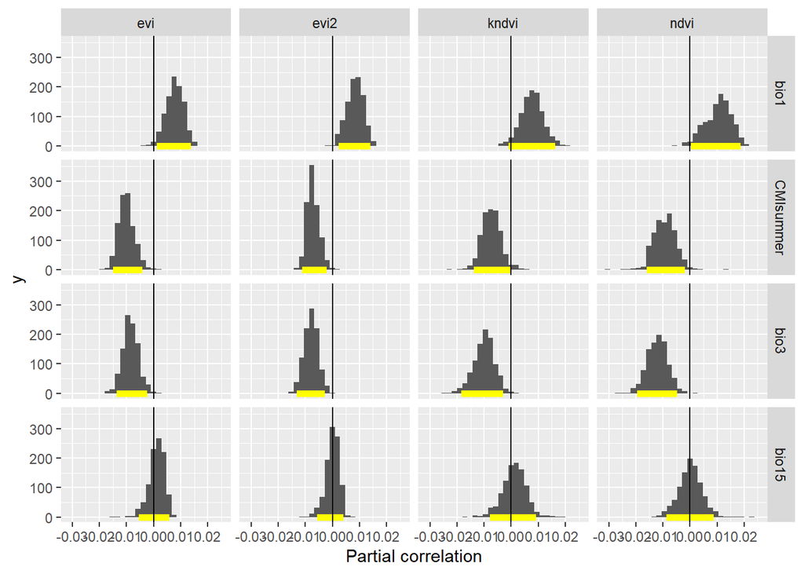

```r
cors2 %>%
  group_by(Index, Clim) %>%
  summarise(Q_2.5 = quantile(R_spearman, probs = 0.025), Q_97.5 = quantile(R_spearman, probs = 0.975)) -> quants

cors2 %>%
  ggplot(aes(x = R_spearman)) +
  geom_histogram() +
  facet_grid(Clim ~ Index) +
  geom_segment(data = quants, aes(x = Q_2.5, xend = Q_97.5, y = 0, yend = 0), color = "yellow", linewidth = 2)+
   geom_vline(xintercept = 0) +
  labs(x = "Partial correlation")
```

Получается, что evi, evi2 и ndvi положительно связаны с bio1 (температура). Все индексы дружно отрицательно коррелируют с CMIsummer (все же что это?) и bio3 (Isothermality (BIO2/BIO7)), а с bio15 вообще ничего не коррелирует.

Можно, также, оценить, на какой из индексов климат оказывает наиболее сильное влияние. Предлагаю рассматривать распределение значений adjusted_R2, полученных для моделей в ресамплинге. Картина получилась вот такая.

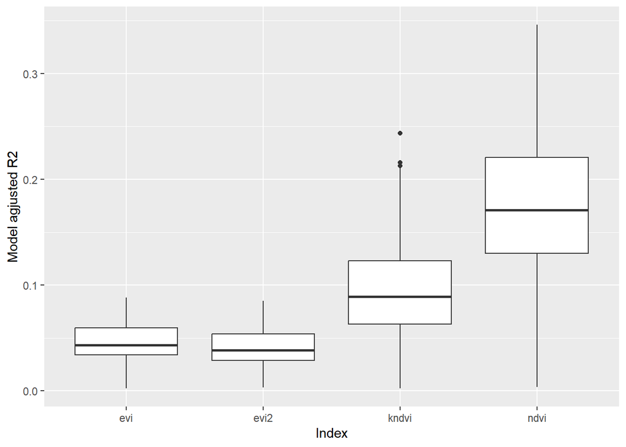

```r
cors %>%
  ggplot(aes(x = Index, y = R2)) +
  geom_boxplot()+
  labs(y ="Model agjusted R2")
```

Получается, в среднем что индекс `ndvi` сильнее всего связан с климатом (17.1017874% дисперсии этого показателя определяется климатическими параметрами).

```r
library(ggpmisc)
Pl1 <-
evi %>%
  merge(clim_short) %>%
  ggplot(aes(x = bio1, y = evi.max)) +
  geom_point() +
  geom_smooth(method = "lm")
# +
#   stat_poly_eq(mapping = use_label(c("R2", "P")), p.digits = 2)
```

```r
Pl2 <-
evi %>%
  merge(clim_short) %>%
  ggplot(aes(x = CMIsummer, y = evi.max)) +
  geom_point() +
  geom_smooth(method = "lm")
# +
#   stat_poly_eq(mapping = use_label(c("R2", "P")), p.digits = 2)
```

```r
Pl3 <-
evi %>%
  merge(clim_short) %>%
  ggplot(aes(x = bio3, y = evi.max)) +
  geom_point() +
  geom_smooth(method = "lm")
# +
#   stat_poly_eq(mapping = use_label(c("R2", "P")), p.digits = 2)
```

```r
Pl4 <-
evi2 %>%
  merge(clim_short) %>%
  ggplot(aes(x = bio1, y = evi2.max)) +
  geom_point() +
  geom_smooth(method = "lm")
# +
#   stat_poly_eq(mapping = use_label(c("R2", "P")), p.digits = 2)
```

```r
Pl5 <-
evi2 %>%
  merge(clim_short) %>%
  ggplot(aes(x = CMIsummer, y = evi2.max)) +
  geom_point() +
  geom_smooth(method = "lm")
# +
#   stat_poly_eq(mapping = use_label(c("R2", "P")), p.digits = 2)
```

```r
Pl6 <-
evi2 %>%
  merge(clim_short) %>%
  ggplot(aes(x = bio3, y = evi2.max)) +
  geom_point() +
  geom_smooth(method = "lm")
# +
#   stat_poly_eq(mapping = use_label(c("R2", "P")), p.digits = 2)
```

```r
Pl7 <-
ndvi %>%
  merge(clim_short) %>%
  ggplot(aes(x = bio1, y = ndvi.max)) +
  geom_point() +
  geom_smooth(method = "lm")
# +
#   stat_poly_eq(mapping = use_label(c("R2", "P")), p.digits = 2)
```

```r
Pl7 <-
ndvi %>%
  merge(clim_short) %>%
  ggplot(aes(x = CMIsummer, y = ndvi.max)) +
  geom_point() +
  geom_smooth(method = "lm")
# +
#   stat_poly_eq(mapping = use_label(c("R2", "P")), p.digits = 2)
```

```r
Pl8 <-
ndvi %>%
  merge(clim_short) %>%
  ggplot(aes(x = bio3, y = ndvi.max)) +
  geom_point() +
  geom_smooth(method = "lm")
# +
#   stat_poly_eq(mapping = use_label(c("R2", "P")), p.digits = 2)
```

```r
Pl9 <-
ndvi %>%
  merge(clim_short) %>%
  ggplot(aes(x = bio1, y = ndvi.max)) +
  geom_point() +
  geom_smooth(method = "lm")
# +
#   stat_poly_eq(mapping = use_label(c("R2", "P")), p.digits = 2)
```

```r
Pl10 <-
ndvi %>%
  merge(clim_short) %>%
  ggplot(aes(x = CMIsummer, y = ndvi.max)) +
  geom_point() +
  geom_smooth(method = "lm")
# +
#   stat_poly_eq(mapping = use_label(c("R2", "P")), p.digits = 2)
```

```r
Pl11 <-
ndvi %>%
  merge(clim_short) %>%
  ggplot(aes(x = bio3, y = ndvi.max)) +
  geom_point() +
  geom_smooth(method = "lm")
# +
#   stat_poly_eq(mapping = use_label(c("R2", "P")), p.digits = 2)
```

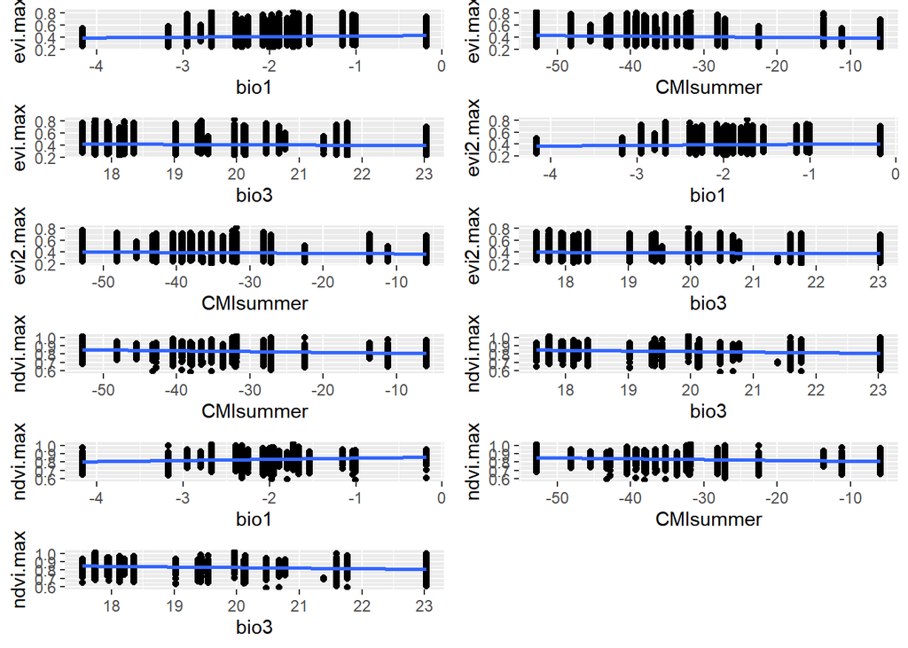

```r
library(cowplot)

plot_grid(Pl1, Pl2, Pl3, Pl4, Pl5, Pl6, Pl7,Pl8,Pl9,Pl10,Pl11,ncol = 2)
```

Приводить на такой модели R2 и p-value можно, но они, ведь, будут “дутые”. Для того и ресамплинг нужен, чтобы устранить проблемы с автокорреляциями и гигантскими выборками (много сайтов), которые будут завышать статистическую значимость модели. По сути эти графики не нужны, так как усредненный характер связи (положительный или отрицательный) виден из распределения значений коэффициентов в ресамплинге.